# Lab-3

eagbozo@urfu.ru

## Plotting Maps

The following packages need to be installed. To install spDataLarge, first install the devtools package install.packages(“devtools”) install.packages(“spDataLarge”, repos = “https://nowosad.github.io/drat/”, type = “source”)

Load packages

```r
library(sf)
library(spData)
library(spDataLarge)



library(tidyverse)
```

we will explore the world dataset

```r
names(world)
```

```
##  [1] "iso_a2"    "name_long" "continent" "region_un" "subregion" "type"
##  [7] "area_km2"  "pop"       "lifeExp"   "gdpPercap" "geom"
```

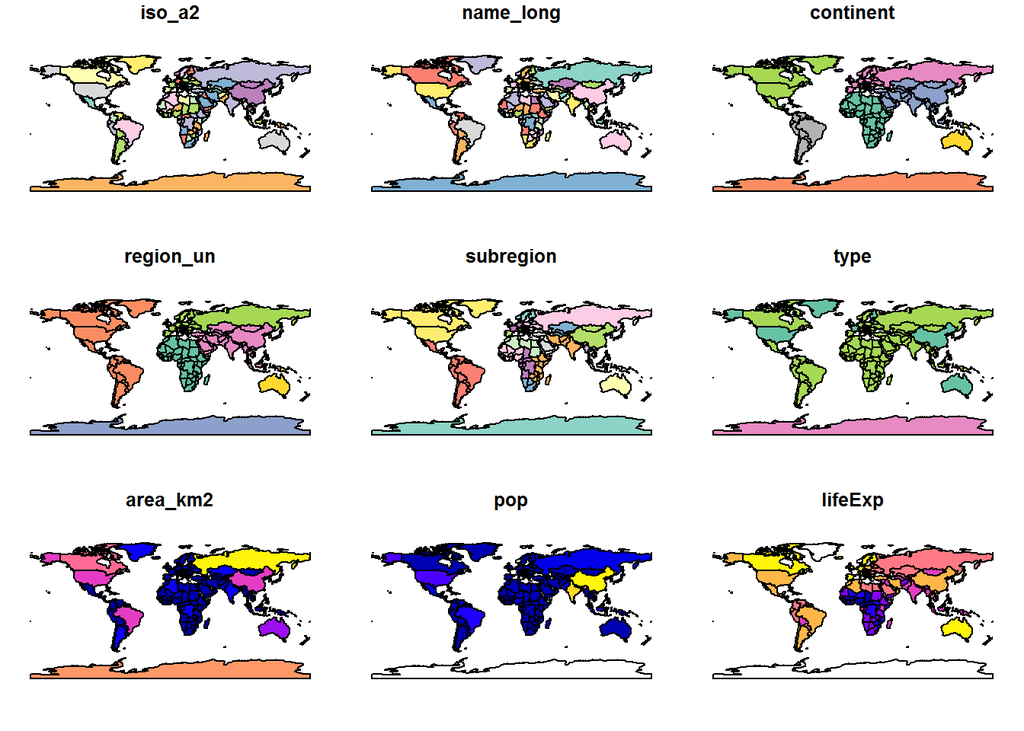

```r
plot(world)
```

let’s check the summary of life expectancy aspect of the dataset

```r
summary(world["lifeExp"])
```

```
##     lifeExp                 geom
##  Min.   :50.62   MULTIPOLYGON :177
##  1st Qu.:64.96   epsg:4326    :  0
##  Median :72.87   +proj=long...:  0
##  Mean   :70.85
##  3rd Qu.:76.78
##  Max.   :83.59
##  NA's   :10
```

we get an extra outuput (notice the geom portion) interpretation —>he mean average life expectancy is 71 years (ranging from less than 51 to more than 83 years with a median of 73 years) across all countries.

MULTIPOLYGON in the summary output above refers to the geometry type of features (countries) in the world object. This representation is necessary for countries with islands such as Indonesia and Greece.

```r
library(tidyverse)

#list all countries
world$name_long
```

```
##   [1] "Fiji"
##   [2] "Tanzania"
##   [3] "Western Sahara"
##   [4] "Canada"
##   [5] "United States"
##   [6] "Kazakhstan"
##   [7] "Uzbekistan"
##   [8] "Papua New Guinea"
##   [9] "Indonesia"
##  [10] "Argentina"
##  [11] "Chile"
##  [12] "Democratic Republic of the Congo"
##  [13] "Somalia"
##  [14] "Kenya"
##  [15] "Sudan"
```

[output cut: 162 more lines]

```r
# world$geom is a ‘list column’ that contains all the coordinates of the country polygons.
```

subset the first three variables (columns) and the first 10 observations from the world dataset

```r
world_small = world %>%
  dplyr::select(iso_a2,name_long,continent) %>%
  head(10)

#or

world_small = world %>%
  dplyr::select(iso_a2,name_long,continent) %>%
  sample_n(size=10)

#note that we use the dplyr:: before the select function due to conflicts with sf package

#explore our new dataset
world_small
```

```
## Simple feature collection with 10 features and 3 fields
## geometry type:  MULTIPOLYGON
## dimension:      XY
## bbox:           xmin: -117.1278 ymin: -16.8013 xmax: 119.1819 ymax: 35.49401
## epsg (SRID):    4326
## proj4string:    +proj=longlat +datum=WGS84 +no_defs
## # A tibble: 10 x 4
##    iso_a2 name_long     continent                                           geom
##    <chr>  <chr>         <chr>                                 <MULTIPOLYGON [°]>
##  1 MW     Malawi        Africa      (((32.75938 -9.230599, 33.73972 -9.41715, 3~
##  2 LB     Lebanon       Asia        (((35.8211 33.27743, 35.5528 33.26427, 35.4~
##  3 MY     Malaysia      Asia        (((100.0858 6.464489, 100.2596 6.642825, 10~
##  4 IN     India         Asia        (((97.32711 28.26158, 97.40256 27.88254, 97~
##  5 SS     South Sudan   Africa      (((30.83385 3.509172, 29.9535 4.173699, 29.~
##  6 PS     Palestine     Asia        (((35.39756 31.48909, 34.92741 31.35344, 34~
##  7 NP     Nepal         Asia        (((88.12044 27.87654, 88.04313 27.44582, 88~
##  8 TT     Trinidad and~ North Amer~ (((-61.68 10.76, -61.105 10.89, -60.895 10.~
##  9 GT     Guatemala     North Amer~ (((-92.22775 14.53883, -92.20323 14.8301, -~
## 10 MX     Mexico        North Amer~ (((-117.1278 32.53534, -115.9913 32.61239, ~
```

plot the 3rd to 6th variables

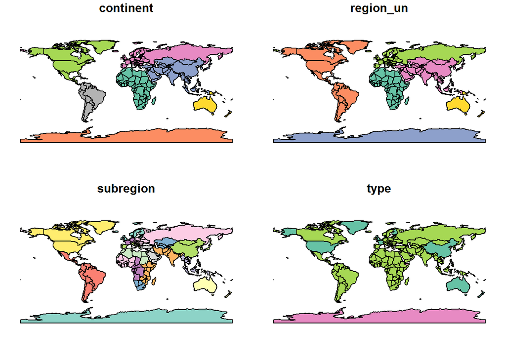

```r
world %>% dplyr::select(c(3:6)) %>%
  plot()
```

plot the world population

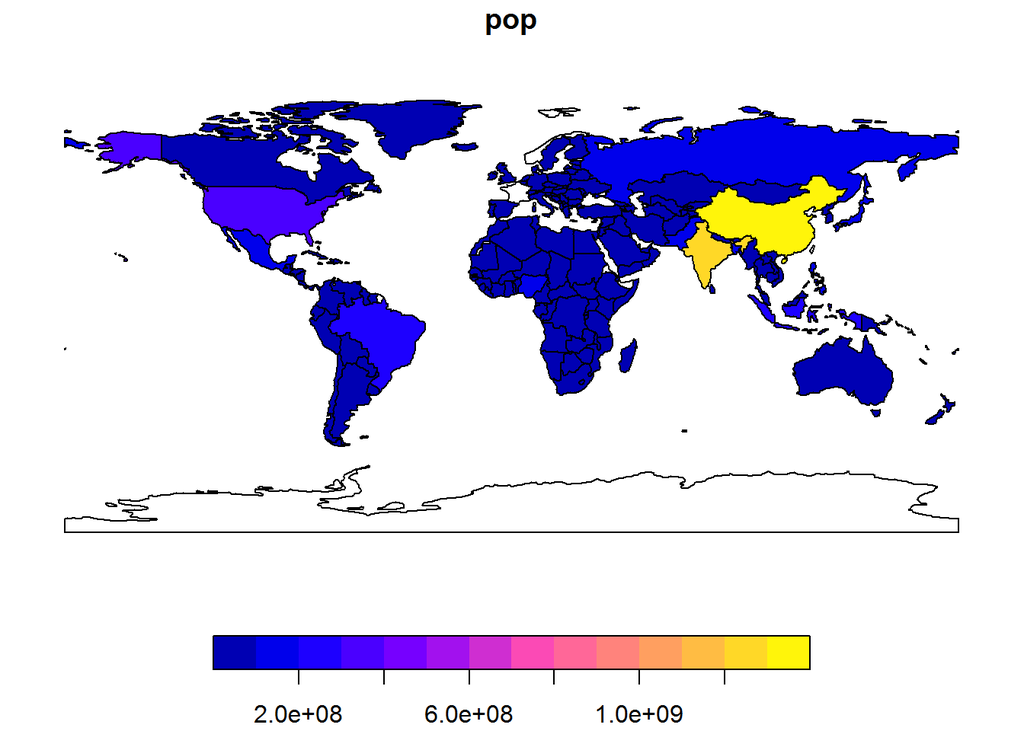

```r
world %>% dplyr::select(pop) %>%
  plot()
```

step 1 - create a dataframe with only Asian countries

```r
w_asia = world %>%
  filter(continent=="Asia")
```

step 2 - Unioning a set of overlapping polygons has the effect of merging the areas (i.e. the same effect as iteratively unioning all individual polygons together). because of the islands

```r
asia = st_union(w_asia)
```

step 3 - plot the world population map

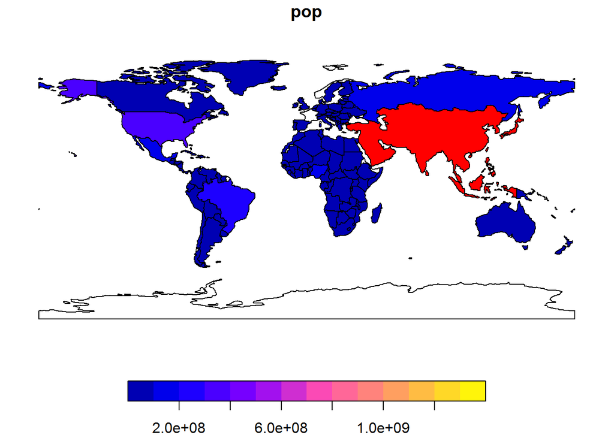

```r
world %>% dplyr::select(pop) %>%
  plot(reset=FALSE)

#step 4 - plot another layer - our Asian data with a color of RED

#add = TRUE makes it possible
#reset = FALSE is necessary for us to superimpose the subsequent plot

  plot(asia, add=TRUE, col="red")
```

Let’s plot world populations with the central points

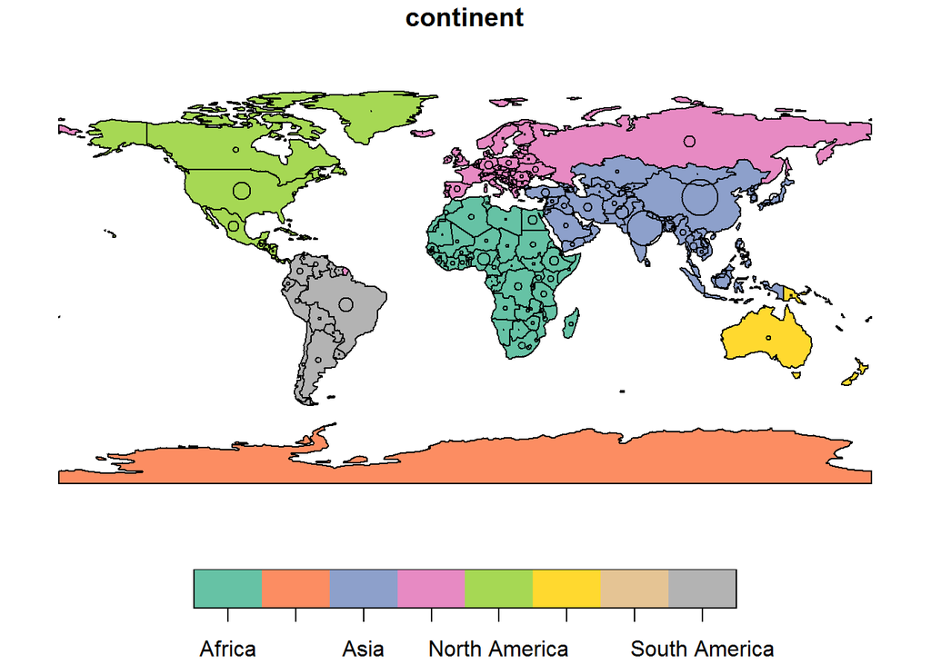

```r
  world %>% dplyr::select(continent) %>%
    plot(reset=FALSE)
  central = sqrt(world$pop)/10000
  world_cents = st_centroid(world,of_largest_polygon = TRUE)
  st_geometry(world_cents) %>%
    plot(add=TRUE, cex=central)
```

let’s plot Russia in context of Europe

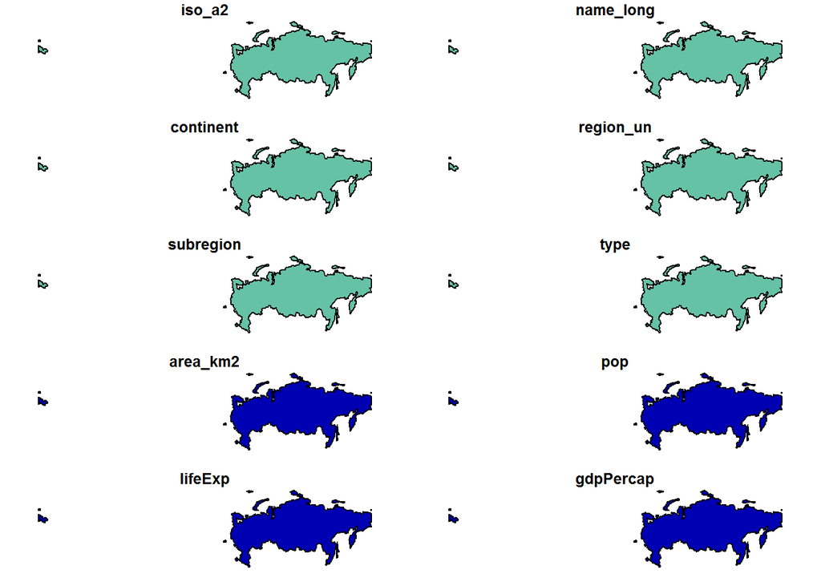

```r
  w_europe = world %>%
    filter(continent=="Europe")

  europe = st_union(w_europe)

  russia = world %>% dplyr::filter(name_long=="Russian Federation")

  plot(russia) #this gives us all plots of Russia
```

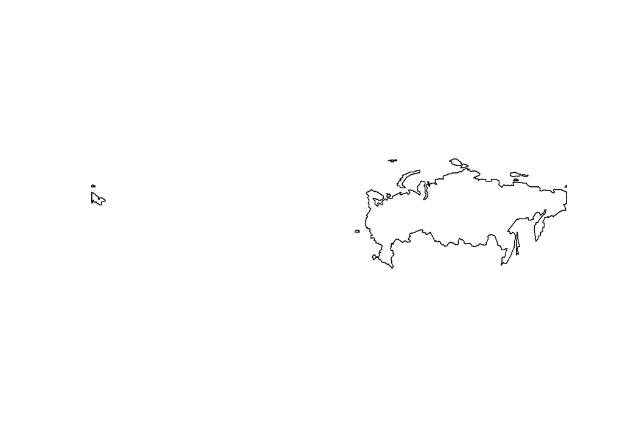

```r
  plot(st_geometry(russia)) #gives us the outline
```

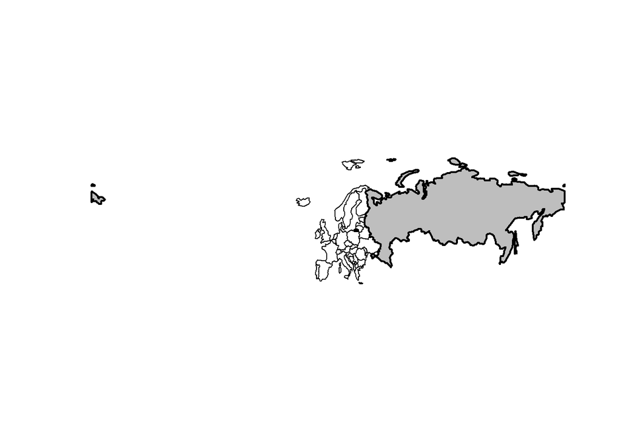

```r
  plot(st_geometry(russia), col="gray", lwd=2) #gives us the outline, fills with gray and line width as 2,
  #we can adjust by including expandBB=c(0,0,0.1,1)

  plot(w_europe[0], add=TRUE) #let's add the european map as a layer, add=TRUE
```